# Praca domowa 2

Daniel Zawadzki

## Dane

Dane wykorzystane w Pracy domowej 2 są związane z kampaniami marketingu bezpośredniego portugalskiej instytucji bankowej. Kampanie marketingowe opierały się na rozmowach telefonicznych. Często wymagany był więcej niż jeden kontakt z tym samym klientem, aby uzyskać dostęp do tego, czy produkt (lokata bankowa) zostanie (lub nie) subskrybowany. Opis wszystkich kolumn znajduje się również w pliku `README.md`.

#### Dane klienta banku

| Zmienna | Opis |
| --- | --- |
| **age** | wiek |
| **job** : admin., unknown, unemployed, management, housemaid, entrepreneur, student, blue-collar, self-employed, retired, technician, services | administrator, nieznany, bezrobotny, kierownictwo, pokojówka, przedsiębiorca, student, pracownik fizyczny, samozatrudniony, emeryt, technik, usługi |
| **marital** : married, divorced, single; note: divorced means divorced or widowed) | żonaty/zamężna, rozwiedzion_, kawaler/panna; uwaga: rozwiedzion_ oznacza rozwiedzion_ lub owdowiał_ |
| **education** : unknown, secondary, primary, tertiary | nieznane, średnie, podstawowe, wyższe |
| **default** : yes, no | czy kredyt jest niespłacany : tak, nie |
| **balance** : average yearly balance, in euros | średnie roczne saldo w euro |
| **housing** : has housing loan? yes, no | czy posiada kredyt mieszkaniowy? tak, nie |
| **loan** : has personal loan? yes, no | ma pożyczkę osobistą? tak, nie |

#### Dane związane z ostatnim kontaktem w bieżącej kampanii

| Zmienna | Opis |
| --- | --- |
| **contact** : unknown, telephone, cellular | nieznany, telefon, komórkowy |
| **day** : last contact day of the month | dzień miesiąca ostatniego kontaktu |
| **month** : last contact month of year, jan, feb, mar, …, nov, dec | miesiąc ostatniego kontaktu w roku, styczeń, luty, marzec, …, listopad, grudzień |
| **duration** : last contact duration, in seconds | czas trwania ostatniego kontaktu w sekundach |

## Zadanie 1

Weźmy pod uwagę zawody (`job`) klientów banku. Który zawód zacząco wyróżnia się w posiadaniu kredytu mieszkaniowego lub pożyczki osobistej?

```r
df %>%
  group_by(job) %>%
  summarise(pozyczka_osobista = mean(loan == 'yes')) %>%
  arrange(-pozyczka_osobista)
```

```
## # A tibble: 12 × 2
##    job           pozyczka_osobista
##    <chr>                     <dbl>
##  1 entrepreneur             0.239
##  2 services                 0.201
##  3 admin.                   0.192
##  4 blue-collar              0.173
##  5 technician               0.172
##  6 self-employed            0.145
##  7 retired                  0.136
##  8 management               0.132
##  9 housemaid                0.123
## 10 unemployed               0.0837
## 11 unknown                  0.0139
## 12 student                  0.0128
```

```r
df %>%
  group_by(job) %>%
  summarise(kredyt_mieszkaniowy = mean(housing == 'yes')) %>%
  arrange(-kredyt_mieszkaniowy)
```

```
## # A tibble: 12 × 2
##    job           kredyt_mieszkaniowy
##    <chr>                       <dbl>
##  1 blue-collar                0.724
##  2 services                   0.666
##  3 admin.                     0.615
##  4 entrepreneur               0.584
##  5 technician                 0.542
##  6 management                 0.495
##  7 self-employed              0.484
##  8 unemployed                 0.417
##  9 housemaid                  0.321
## 10 student                    0.265
## 11 retired                    0.217
## 12 unknown                    0.0903
```

**Komentarz: Najwięcej pożyczek biorą przedsiębiorcy, a zdecydowanie najmniej ich biorą studenci i osoby o nieznanym zawodzie. Kredyt mieszkaniowy najczęściej biorą pracownicy fizyczni, najrzadziej osoby o nieznanym zawodzie**

## Zadanie 2

Wybierając klientów, którzy mają nieznany sposób kontaktu (`contact`). Jak rozkłada się ich wiek w podziale na status związku?

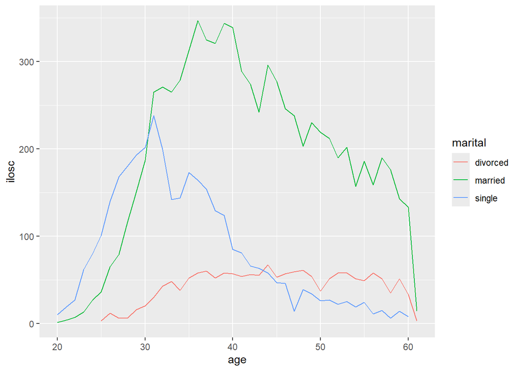

```r
df %>%
  filter(contact == 'unknown') %>%
  group_by(marital,age) %>%
  summarise(ilosc = n()) %>%
  ggplot(aes(x = age, y = ilosc, color = marital)) +
    geom_line()
```

**Komentarz: Wśród singli zdecydowanie najwięcej osób jest około 30 roku życia. Wśród osób w związku małżeńskim najwięcej osób jest w wieku 35-40 lat oraz ilość osób szybciej spada, gdy spojżymy na osoby młodsze niż starsze od podanego przedziału wiekowego. Wśród osób rozwiedzionych lub owdowiałych liczba osób w danym wieku jest dosyć podobna, oprócz osób poniżej 30 lat, których jest zdecydowanie najmniej.**

## Zadanie 3

Jaka jest różnica pomiędzy średnim rocznym saldem w euro w zależności od wykształcenia i tego czy kredyt jest niespłacany?

```r
df %>%
  group_by(education) %>%
  summarise(srednie_roczne_saldo = mean(balance))
```

```
## # A tibble: 4 × 2
##   education srednie_roczne_saldo
##   <chr>                    <dbl>
## 1 primary                  1251.
## 2 secondary                1155.
## 3 tertiary                 1758.
## 4 unknown                  1527.
```

```r
df %>%
  group_by(default) %>%
  summarise(srednie_roczne_saldo = mean(balance))
```

```
## # A tibble: 2 × 2
##   default srednie_roczne_saldo
##   <chr>                  <dbl>
## 1 no                     1390.
## 2 yes                    -138.
```

## Zadanie 4

Czy dzień i miesiąc kontaktu z klientem ma wpływ na średni czas trwania rozmowy w stosunku do średniego czasu trwania rozmowy?

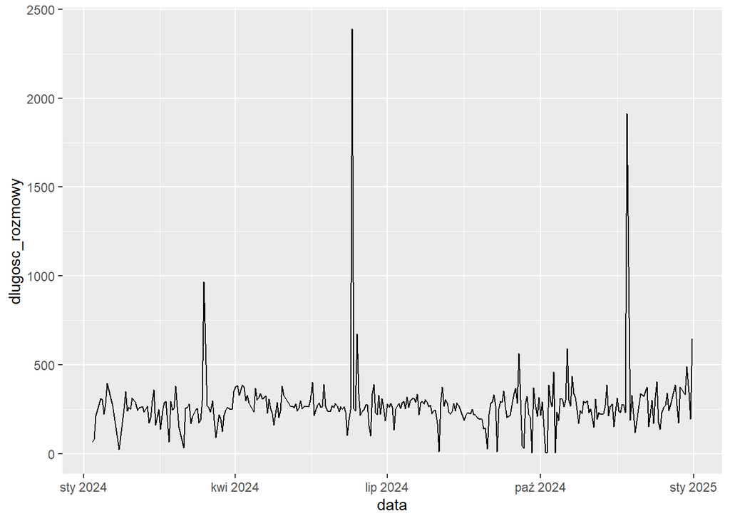

```r
df %>%
  mutate(month_num = case_when(
      month == "jan" ~ 01,
      month == "feb" ~ 02,
      month == "mar" ~ 03,
      month == "apr" ~ 04,
      month == "may" ~ 05,
      month == "jun" ~ 06,
      month == "jul" ~ 07,
      month == "aug" ~ 08,
      month == "sep" ~ 09,
      month == "oct" ~ 10,
      month == "nov" ~ 11,
      month == "dec" ~ 12)) %>%
  mutate(data = as.Date(paste(day,month_num,'2024'), "%d %m %Y")) %>%
  group_by(data) %>%
  summarise(dlugosc_rozmowy = mean(duration)) %>%
  ggplot(aes(x = data, y = dlugosc_rozmowy)) +
    geom_line()
```

**Komentarz: Nie zależności między dniem i miesiącem ostatniego kontaktu z klientem i średnim czasem rozmowy.**

## Zadanie 5

Czy jest zależnośc pomiędzy wiekiem klientów a ich średnim rocznym saldzie w euro w podziale na stopień wykształcenia?

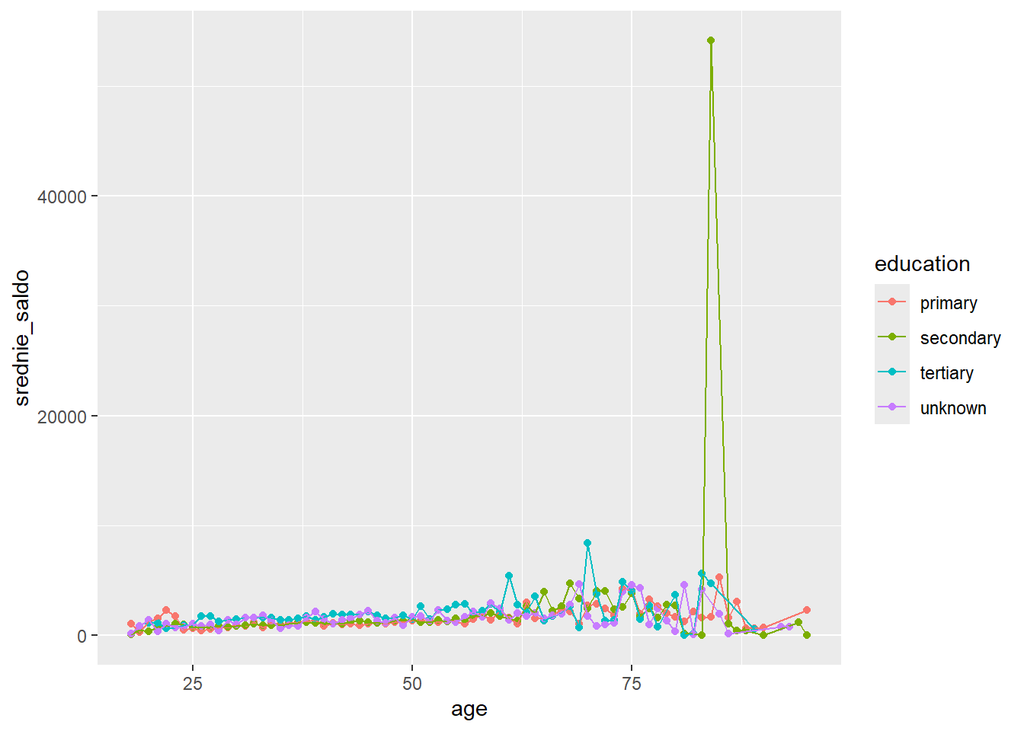

```r
df %>%
  group_by(age, education) %>%
  summarise(srednie_saldo = mean(balance)) %>%
  ggplot(aes(x = age, y = srednie_saldo, color = education)) +
    geom_point() +
    geom_line()
```

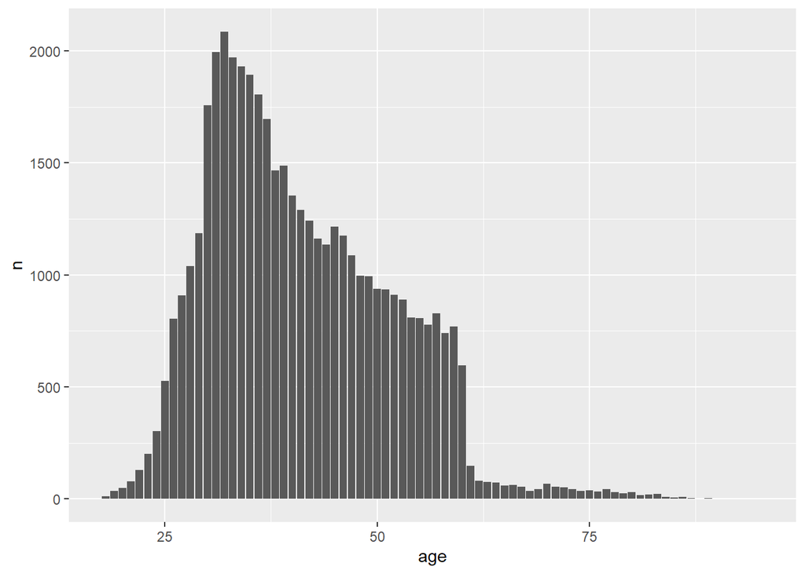

```r
df %>%
  group_by(age) %>%
  summarise(n=n()) %>%
  ggplot(aes(x = age, y = n))+
    geom_col()
```

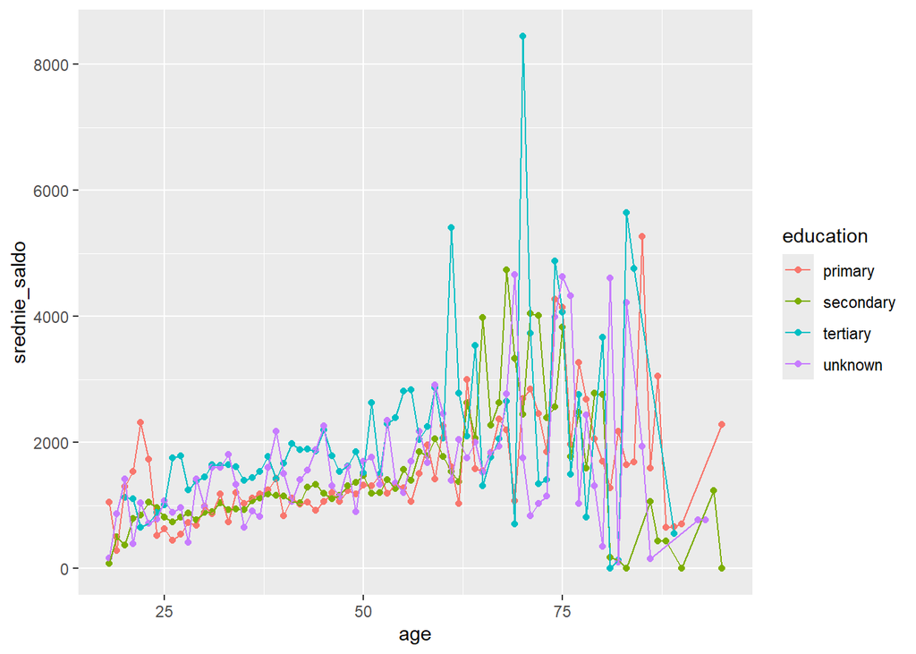

```r
df %>%
  group_by(age, education) %>%
  summarise(srednie_saldo = mean(balance)) %>%
  filter(srednie_saldo<40000) %>%
  ggplot(aes(x = age, y = srednie_saldo, color = education)) +
    geom_point() +
    geom_line()
```

**Komentarz: W powyższym wykresie pominąłem skrajny przypadek osób w wieku 84 z średnim wykształceniem, który znacząco przewyzszał pozostałe, przez niewielką liczbę osób starszych w danych. Widać, że wraz z wiekiem rośnie średnie saldo konta, niezależnie od wykształcenia, o ile jest ono znane. Duże wachania w skrajnych grupach wiekowych są prawdopodobnie powodowane przez mniejszą liczbę osób w danym wieku.**

## Zadanie 6

Rozważmy osoby, które są bezrobotne albo ich zawód jest nieznany. Czy procent osób, które są bezrobotne i nie spłacają kredytu jest większy od procenta osób o nieznanym zawodzie i nie spłacanym kredycie? Jaki typ kredytu jest (przez te osoby) najczęściej niespłacany?

```r
bezrobotni <- df %>%
  filter(job %in% 'unemployed') %>%
  group_by(job) %>%
  summarise(n = n())
bezrobotni_nie_splacili <- df %>%
  filter(job %in% 'unemployed', default %in% 'no') %>%
  group_by(job) %>%
  summarise(n = n())
bezrobotni_nie_splacili$n / bezrobotni$n
```

```
## [1] 0.9769762
```

```r
nieznani <- df %>%
  filter(job %in% 'unknown') %>%
  group_by(job) %>%
  summarise(n = n())
nieznani_nie_splacili <- df %>%
  filter(job %in% 'unknown', default %in% 'no') %>%
  group_by(job) %>%
  summarise(n = n())
nieznani_nie_splacili$n / nieznani$n
```

```
## [1] 0.9930556
```

```r
df %>%
  filter(job %in% c('unknown','unemployed')) %>%
  group_by(housing,loan) %>%
  summarise(n = n())
```

```
## # A tibble: 4 × 3
## # Groups:   housing [2]
##   housing loan      n
##   <chr>   <chr> <int>
## 1 no      no      974
## 2 no      yes      48
## 3 yes     no      504
## 4 yes     yes      65
```